# **Laboratorio 14 - Minería de texto**

## **Integrantes**:

### - Moscoso Chumpitaz, Ricardo Emmanuel

## Parte a)

Cree una sesión en Spark, lea los datos, muéstrelos sin truncamiento, seleccione solamente las variables ‘SentimentText’ y ‘Sentiment’, y verifique si tiene valores nulos.

**Sesión spark**

```python
# Instalación del paquete de pyspark
#!pip install pyspark findspark
#!pip install py4j
```

```python
# Importación de librerías
from pyspark import SparkConf, SparkContext
from pyspark.sql import SparkSession
```

```python
#sc = SparkContext(master = "local[2]")
#sc
```

```python
spark = SparkSession.builder.appName("Clasificación_texto").getOrCreate()
spark
```

**SparkSession - in-memory**

**SparkContext**

[Spark UI](http://f43fc56aa4e8:4040)

**Version**

`v3.5.0`

**Master**

`local[2]`

**AppName**

`pyspark-shell`

**Lectura de datos**

```python
data = spark.read.csv("tweets.csv",header=True,inferSchema=True)
data.show()
```

```
+------+---------+---------------+--------------------+
|ItemID|Sentiment|SentimentSource|       SentimentText|
+------+---------+---------------+--------------------+
|  1038|        1|   Sentiment140|that film is fant...|
|  1804|        1|   Sentiment140|this music is rea...|
|  1693|        0|   Sentiment140|winter is terribl...|
|  1477|        0|   Sentiment140|this game is awfu...|
|    45|        1|   Sentiment140|  I love jam #loveit|
|   246|        0|   Sentiment140|I dislike skiing ...|
|   776|        1|   Sentiment140|I like pop music ...|
|  1666|        1|   Sentiment140|this game is awfu...|
|  1237|        0|   Sentiment140|rock music is ter...|
|  1386|        1|   Sentiment140|that movie is gre...|
|   695|        0|   Sentiment140|I hate this game ...|
|   649|        0|   Sentiment140|I dislike this ga...|
|  1565|        1|   Sentiment140|that movie is gre...|
|   150|        1|   Sentiment140|I like tea #brill...|
|  1500|        1|   Sentiment140|this game is terr...|
|  1781|        0|   Sentiment140|this game is terr...|
|   884|        1|   Sentiment140|this game is bril...|
|  1793|        0|   Sentiment140|jam is terrible #...|
|  1782|        0|   Sentiment140|coffee is terribl...|
|   921|        0|   Sentiment140|that movie is awf...|
+------+---------+---------------+--------------------+
only showing top 20 rows
```

**Lectura de datos sin truncamiento**

```python
data.show(10,truncate=False)
```

```
+------+---------+---------------+---------------------------------+
|ItemID|Sentiment|SentimentSource|SentimentText                    |
+------+---------+---------------+---------------------------------+
|1038  |1        |Sentiment140   |that film is fantastic #brilliant|
|1804  |1        |Sentiment140   |this music is really bad #myband |
|1693  |0        |Sentiment140   |winter is terrible #thumbs-down  |
|1477  |0        |Sentiment140   |this game is awful #nightmare    |
|45    |1        |Sentiment140   |I love jam #loveit               |
|246   |0        |Sentiment140   |I dislike skiing #rubbish        |
|776   |1        |Sentiment140   |I like pop music #toptastic      |
|1666  |1        |Sentiment140   |this game is awful good          |
|1237  |0        |Sentiment140   |rock music is terrible #worstever|
|1386  |1        |Sentiment140   |that movie is great #favorite    |
+------+---------+---------------+---------------------------------+
only showing top 10 rows
```

**Selección de variables ‘SentimentText’ y ‘Sentiment'**

```python
# Seleccionar columnas
data.columns
data = data.select("SentimentText","Sentiment")
data.show()
```

```
+--------------------+---------+
|       SentimentText|Sentiment|
+--------------------+---------+
|that film is fant...|        1|
|this music is rea...|        1|
|winter is terribl...|        0|
|this game is awfu...|        0|
|  I love jam #loveit|        1|
|I dislike skiing ...|        0|
|I like pop music ...|        1|
|this game is awfu...|        1|
|rock music is ter...|        0|
|that movie is gre...|        1|
|I hate this game ...|        0|
|I dislike this ga...|        0|
|that movie is gre...|        1|
|I like tea #brill...|        1|
|this game is terr...|        1|
|this game is terr...|        0|
|this game is bril...|        1|
|jam is terrible #...|        0|
|coffee is terribl...|        0|
|that movie is awf...|        0|
+--------------------+---------+
only showing top 20 rows
```

**Verificación de valores nulos**

```python
from pyspark.sql import functions as F
data_null = data.select(*(F.sum(F.col(c).isNull(). \
                                cast("Integer")).alias(c) for c in data.columns)).toPandas()
data_null
```

|  | SentimentText | Sentiment |
| --- | --- | --- |
| 0 | 0 | 0 |

### Comentario: No existen valores nulos en las variables 'SentimentText' y 'Sentiment'

## Parte b

Realice transformaciones de tokenización, remover palabras stop, vector de conteo e Inverse Document Frequency (IDF) para la variable ‘SentimentText’. Además, indexe la variable de clasificación, tome un 75% de los datos para el entrenamiento y un 25% para la prueba, e implemente un modelo de regresión logística con los datos de entrenamiento.

```python
import pyspark.ml.feature
```

```python
from pyspark.ml.feature import Tokenizer, StopWordsRemover,CountVectorizer,IDF
from pyspark.ml.feature import StringIndexer
```

```python
# Transformaciones de tokenización para la variable "SentimentText"
tokenizer = Tokenizer(inputCol="SentimentText",outputCol="tokens")
tokenizerdata = tokenizer.transform(data)
tokenizerdata.show(5,truncate=False)
```

```
+---------------------------------+---------+---------------------------------------+
|SentimentText                    |Sentiment|tokens                                 |
+---------------------------------+---------+---------------------------------------+
|that film is fantastic #brilliant|1        |[that, film, is, fantastic, #brilliant]|
|this music is really bad #myband |1        |[this, music, is, really, bad, #myband]|
|winter is terrible #thumbs-down  |0        |[winter, is, terrible, #thumbs-down]   |
|this game is awful #nightmare    |0        |[this, game, is, awful, #nightmare]    |
|I love jam #loveit               |1        |[i, love, jam, #loveit]                |
+---------------------------------+---------+---------------------------------------+
only showing top 5 rows
```

```python
# Removiendo las palabras stop, vector de conteo e Inverse Document Frequency (IDF)
stopwords_remover = StopWordsRemover(inputCol="tokens",outputCol="filtered_tokens")
vectorizer = CountVectorizer(inputCol="filtered_tokens",outputCol="raw_features")
idf = IDF(inputCol="raw_features",outputCol="vectorized_features")
```

```python
# Indexión de la variable de clasificación
label_encoder = StringIndexer(inputCol="Sentiment",outputCol="sentiment_num").fit(data)
label_encoder.transform(data).show()
label_encoder.labels
```

```
+--------------------+---------+-------------+
|       SentimentText|Sentiment|sentiment_num|
+--------------------+---------+-------------+
|that film is fant...|        1|          1.0|
|this music is rea...|        1|          1.0|
|winter is terribl...|        0|          0.0|
|this game is awfu...|        0|          0.0|
|  I love jam #loveit|        1|          1.0|
|I dislike skiing ...|        0|          0.0|
|I like pop music ...|        1|          1.0|
|this game is awfu...|        1|          1.0|
|rock music is ter...|        0|          0.0|
|that movie is gre...|        1|          1.0|
|I hate this game ...|        0|          0.0|
|I dislike this ga...|        0|          0.0|
|that movie is gre...|        1|          1.0|
|I like tea #brill...|        1|          1.0|
|this game is terr...|        1|          1.0|
|this game is terr...|        0|          0.0|
|this game is bril...|        1|          1.0|
|jam is terrible #...|        0|          0.0|
|coffee is terribl...|        0|          0.0|
|that movie is awf...|        0|          0.0|
+--------------------+---------+-------------+
only showing top 20 rows
```

```
['0', '1']
```

```python
# Preparación del objeto 'data' previa separación de datos de entrenamiento y prueba
data = label_encoder.transform(data)
```

```python
data.show()
```

```
+--------------------+---------+-------------+
|       SentimentText|Sentiment|sentiment_num|
+--------------------+---------+-------------+
|that film is fant...|        1|          1.0|
|this music is rea...|        1|          1.0|
|winter is terribl...|        0|          0.0|
|this game is awfu...|        0|          0.0|
|  I love jam #loveit|        1|          1.0|
|I dislike skiing ...|        0|          0.0|
|I like pop music ...|        1|          1.0|
|this game is awfu...|        1|          1.0|
|rock music is ter...|        0|          0.0|
|that movie is gre...|        1|          1.0|
|I hate this game ...|        0|          0.0|
|I dislike this ga...|        0|          0.0|
|that movie is gre...|        1|          1.0|
|I like tea #brill...|        1|          1.0|
|this game is terr...|        1|          1.0|
|this game is terr...|        0|          0.0|
|this game is bril...|        1|          1.0|
|jam is terrible #...|        0|          0.0|
|coffee is terribl...|        0|          0.0|
|that movie is awf...|        0|          0.0|
+--------------------+---------+-------------+
only showing top 20 rows
```

```python
# Separamos los datos en entrenamiento (0.75) y prueba (0.25)
(train,test) = data.randomSplit((0.75,0.25),seed=32)
train.show()
```

```
+--------------------+---------+-------------+
|       SentimentText|Sentiment|sentiment_num|
+--------------------+---------+-------------+
|I adore cheese #b...|        1|          1.0|
|I adore cheese #b...|        1|          1.0|
|I adore cheese #f...|        1|          1.0|
|I adore cheese #l...|        1|          1.0|
|I adore cheese #t...|        1|          1.0|
|I adore classical...|        1|          1.0|
|I adore classical...|        1|          1.0|
|I adore classical...|        1|          1.0|
|I adore classical...|        1|          1.0|
|I adore classical...|        1|          1.0|
|I adore coffee #b...|        1|          1.0|
|I adore coffee #b...|        1|          1.0|
|I adore coffee #f...|        1|          1.0|
|I adore coffee #l...|        1|          1.0|
|I adore jam #best...|        1|          1.0|
|I adore jam #favo...|        1|          1.0|
| I adore jam #loveit|        1|          1.0|
|I adore jam #thum...|        1|          1.0|
|I adore pop music...|        1|          1.0|
|I adore pop music...|        1|          1.0|
+--------------------+---------+-------------+
only showing top 20 rows
```

**Creación de modelo de regresión logística**

```python
from pyspark.ml.classification import LogisticRegression
lr_model = LogisticRegression(featuresCol="vectorized_features",labelCol="sentiment_num")
lr_model
```

```
LogisticRegression_eaa2025d275b
```

```python
# Tubería con transformaciones
from pyspark.ml import Pipeline
pipeline = Pipeline(stages=[tokenizer,stopwords_remover, vectorizer,idf,lr_model])
pipeline
```

```
Pipeline_6b5ab61804c6
```

```python
# Método fit sobre tubería
lr_model=pipeline.fit(train)
lr_model
```

```
PipelineModel_6d0f44afe512
```

## Parte c

Realice predicciones a partir de los datos de prueba y mida su desempeño por medio de las métricas área de la curva ROC, accuracy, F1 score, precision y recall. Además, halle la matriz de confusión y un reporte de métricas con las etiquetas ‘Positivo’ para 1 y ‘Negativo’ para 0. Por último, indique cómo se clasificaría el comentario I believe the tea is good.

**Predicciones a partir de datos de prueba - método 'transform'**

```python
predictions = lr_model.transform(test)
predictions.show()
```

```
+--------------------+---------+-------------+--------------------+--------------------+--------------------+--------------------+--------------------+--------------------+----------+
|       SentimentText|Sentiment|sentiment_num|              tokens|     filtered_tokens|        raw_features| vectorized_features|       rawPrediction|         probability|prediction|
+--------------------+---------+-------------+--------------------+--------------------+--------------------+--------------------+--------------------+--------------------+----------+
|I adore cheese #t...|        1|          1.0|[i, adore, cheese...|[adore, cheese, #...|(48,[12,29,42],[1...|(48,[12,29,42],[2...|[-43.681633333561...|[1.06981253621515...|       1.0|
|I adore classical...|        1|          1.0|[i, adore, classi...|[adore, classical...|(48,[0,14,29,37],...|(48,[0,14,29,37],...|[-43.349112843536...|[1.491830550604E-...|       1.0|
|I adore coffee #t...|        1|          1.0|[i, adore, coffee...|[adore, coffee, #...|(48,[12,29,40],[1...|(48,[12,29,40],[2...|[-45.198377499269...|[2.34743762425956...|       1.0|
|I adore coffee #t...|        1|          1.0|[i, adore, coffee...|[adore, coffee, #...|(48,[18,29,40],[1...|(48,[18,29,40],[2...|[-44.507228050395...|[4.68550550970084...|       1.0|
|I adore jam #bril...|        1|          1.0|[i, adore, jam, #...|[adore, jam, #bri...|(48,[17,29,34],[1...|(48,[17,29,34],[2...|[-46.008708793020...|[1.04393065710894...|       1.0|
|I adore jam #topt...|        1|          1.0|[i, adore, jam, #...|[adore, jam, #top...|(48,[18,29,34],[1...|(48,[18,29,34],[2...|[-44.588977456546...|[4.31770669358600...|       1.0|
|I adore pop music...|        1|          1.0|[i, adore, pop, m...|[adore, pop, musi...|(48,[0,11,29,41],...|(48,[0,11,29,41],...|[-76.917894464850...|[3.93534556750263...|       1.0|
|I adore rock musi...|        1|          1.0|[i, adore, rock, ...|[adore, rock, mus...|(48,[0,14,29,43],...|(48,[0,14,29,43],...|[-45.141629170870...|[2.48450312289456...|       1.0|
|I adore rock musi...|        1|          1.0|[i, adore, rock, ...|[adore, rock, mus...|(48,[0,11,29,43],...|(48,[0,11,29,43],...|[-76.726066362773...|[4.76752260053963...|       1.0|
|I adore rock musi...|        1|          1.0|[i, adore, rock, ...|[adore, rock, mus...|(48,[0,3,29,43],[...|(48,[0,3,29,43],[...|[-45.901751019962...|[1.16177712826572...|       1.0|
|I adore rock musi...|        1|          1.0|[i, adore, rock, ...|[adore, rock, mus...|(48,[0,18,29,43],...|(48,[0,18,29,43],...|[-44.482994231932...|[4.80044022835444...|       1.0|
|I adore skiing #f...|        1|          1.0|[i, adore, skiing...|[adore, skiing, #...|(48,[11,29,39],[1...|(48,[11,29,39],[2...|[-76.761688008207...|[4.60068476140131...|       1.0|
|I adore tea #best...|        1|          1.0|[i, adore, tea, #...|[adore, tea, #bes...|(48,[14,29,36],[1...|(48,[14,29,36],[2...|[-45.205145630524...|[2.33160350245650...|       1.0|
|I adore that band...|        1|          1.0|[i, adore, that, ...|[adore, band, #be...|(48,[10,14,29],[1...|(48,[10,14,29],[2...|[-45.261334384358...|[2.20420626929828...|       1.0|
|I adore that band...|        1|          1.0|[i, adore, that, ...|[adore, band, #br...|(48,[10,17,29],[1...|(48,[10,17,29],[2...|[-46.022430781894...|[1.02970368664793...|       1.0|
|I adore that film...|        1|          1.0|[i, adore, that, ...|[adore, film, #br...|(48,[5,17,29],[1....|(48,[5,17,29],[2....|[-46.998960110059...|[3.87802825519104...|       1.0|
|I adore that film...|        1|          1.0|[i, adore, that, ...|[adore, film, #to...|(48,[5,18,29],[1....|(48,[5,18,29],[2....|[-45.579228773585...|[1.60395601387216...|       1.0|
|I adore that movi...|        0|          0.0|[i, adore, that, ...|[adore, movie, #t...|(48,[6,18,29],[1....|(48,[6,18,29],[2....|[-42.904384927642...|[2.32735362597491...|       1.0|
|I adore the holid...|        1|          1.0|[i, adore, the, h...|[adore, holidays,...|(48,[14,29,38],[1...|(48,[14,29,38],[2...|[-45.113365171371...|[2.55572691108598...|       1.0|
|I adore this band...|        1|          1.0|[i, adore, this, ...|[adore, band, #be...|(48,[10,14,29],[1...|(48,[10,14,29],[2...|[-45.261334384358...|[2.20420626929828...|       1.0|
+--------------------+---------+-------------+--------------------+--------------------+--------------------+--------------------+--------------------+--------------------+----------+
only showing top 20 rows
```

```python
predictions.select('rawPrediction','sentiment_num', 'probability','prediction').show()
```

```
+--------------------+-------------+--------------------+----------+
|       rawPrediction|sentiment_num|         probability|prediction|
+--------------------+-------------+--------------------+----------+
|[-43.681633333561...|          1.0|[1.06981253621515...|       1.0|
|[-43.349112843536...|          1.0|[1.491830550604E-...|       1.0|
|[-45.198377499269...|          1.0|[2.34743762425956...|       1.0|
|[-44.507228050395...|          1.0|[4.68550550970084...|       1.0|
|[-46.008708793020...|          1.0|[1.04393065710894...|       1.0|
|[-44.588977456546...|          1.0|[4.31770669358600...|       1.0|
|[-76.917894464850...|          1.0|[3.93534556750263...|       1.0|
|[-45.141629170870...|          1.0|[2.48450312289456...|       1.0|
|[-76.726066362773...|          1.0|[4.76752260053963...|       1.0|
|[-45.901751019962...|          1.0|[1.16177712826572...|       1.0|
|[-44.482994231932...|          1.0|[4.80044022835444...|       1.0|
|[-76.761688008207...|          1.0|[4.60068476140131...|       1.0|
|[-45.205145630524...|          1.0|[2.33160350245650...|       1.0|
|[-45.261334384358...|          1.0|[2.20420626929828...|       1.0|
|[-46.022430781894...|          1.0|[1.02970368664793...|       1.0|
|[-46.998960110059...|          1.0|[3.87802825519104...|       1.0|
|[-45.579228773585...|          1.0|[1.60395601387216...|       1.0|
|[-42.904384927642...|          0.0|[2.32735362597491...|       1.0|
|[-45.113365171371...|          1.0|[2.55572691108598...|       1.0|
|[-45.261334384358...|          1.0|[2.20420626929828...|       1.0|
+--------------------+-------------+--------------------+----------+
only showing top 20 rows
```

**Métricas de desempeño**

```python
from pyspark.ml.evaluation import BinaryClassificationEvaluator
b_evaluator = BinaryClassificationEvaluator(labelCol="sentiment_num")
roc = b_evaluator.evaluate(predictions,{b_evaluator.metricName:"areaUnderROC"})
print("Área de la curva ROC: {0}".format(roc))

from pyspark.ml.evaluation import MulticlassClassificationEvaluator
evaluator = MulticlassClassificationEvaluator(labelCol="sentiment_num",
            predictionCol="prediction",metricName="accuracy")
accuracy = evaluator.evaluate(predictions)
print("Accuracy = %g" % accuracy)

evaluatorf1 = MulticlassClassificationEvaluator(labelCol="sentiment_num",
              predictionCol="prediction",metricName="f1")
f1 = evaluatorf1.evaluate(predictions)
print("F1 score = %g" % f1)

evaluatorwp = MulticlassClassificationEvaluator(labelCol="sentiment_num",
              predictionCol="prediction",metricName="weightedPrecision")
wp = evaluatorwp.evaluate(predictions)
print("Precision = %g" % wp)

evaluatorwr = MulticlassClassificationEvaluator(labelCol="sentiment_num",
              predictionCol="prediction",metricName="weightedRecall")
wr = evaluatorwr.evaluate(predictions)
print("Recall = %g" % wr)
```

```
Área de la curva ROC: 0.9800569800569823
Accuracy = 0.982796
F1 score = 0.982795
Precision = 0.98283
Recall = 0.982796
```

```python
# Predicciones
y = predictions.select("sentiment_num")
y = y.toPandas()
y_pred = predictions.select("prediction")
y_pred = y_pred.toPandas()
```

**Matriz de confusión y un reporte de métricas**

```python
# Matriz de confusión
from sklearn.metrics import confusion_matrix, classification_report
CM = confusion_matrix(y,y_pred)
CM
```

```
array([[226,   5],
       [  3, 231]])
```

```python
# Matriz de confusión gráfica - función
import matplotlib.pyplot as plt
import numpy as np
import itertools
def plot_confusion_matrix(cm, classes,
                          normalize=False,
                          title='Matriz de confusión',
                          cmap=plt.cm.Blues):
  if normalize:
    cm = cm.astype('float') / cm.sum(axis=1)[:, np.newaxis]
    print("Matriz de confusión normalizada")
  else:
    print('Matriz de confusión sin normalizar')

  print(cm)

  plt.imshow(cm, interpolation='nearest', cmap=cmap)
  plt.title(title)
  plt.colorbar()
  tick_marks = np.arange(len(classes))
  plt.xticks(tick_marks, classes, rotation=45)
  plt.yticks(tick_marks, classes)

  fmt = '.2f' if normalize else 'd'
  thresh = cm.max() / 2.
  for i, j in itertools.product(range(cm.shape[0]), range(cm.shape[1])):
      plt.text(j, i, format(cm[i, j], fmt),
               horizontalalignment="center",
               color="white" if cm[i, j] > thresh else "black")
  plt.tight_layout()
  plt.ylabel('True label')
```

```python
# Etiqueta de datos para ‘Positivo’ para 1 y ‘Negativo’ para 0
class_names = ['Positivo = 1' ,'Negativo = 0']
```

```
Matriz de confusión sin normalizar
[[226   5]
 [  3 231]]
              precision    recall  f1-score   support

Positivo = 1       0.99      0.98      0.98       231
Negativo = 0       0.98      0.99      0.98       234

    accuracy                           0.98       465
   macro avg       0.98      0.98      0.98       465
weighted avg       0.98      0.98      0.98       465
```

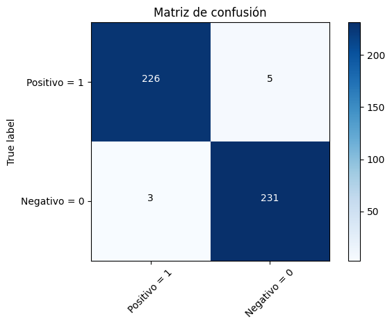

```python
# Aplicación de función
plot_confusion_matrix(CM,class_names)
print(classification_report(y,y_pred,target_names=class_names))
```

**Clasificación del comentario "I believe the tea is good"**

```python
# Nueva predicción
from pyspark.sql.types import StringType
new = spark.createDataFrame([("I believe the tea is good", StringType())],["SentimentText"])
new.show(truncate=False)
```

```
+-------------------------+---+
|SentimentText            |_2 |
+-------------------------+---+
|I believe the tea is good|{} |
+-------------------------+---+
```

```python
# Aplicación del modelo
pred_new = lr_model.transform(new)
pred_new.show()
```

```
+--------------------+---+--------------------+--------------------+--------------------+--------------------+--------------------+--------------------+----------+
|       SentimentText| _2|              tokens|     filtered_tokens|        raw_features| vectorized_features|       rawPrediction|         probability|prediction|
+--------------------+---+--------------------+--------------------+--------------------+--------------------+--------------------+--------------------+----------+
|I believe the tea...| {}|[i, believe, the,...|[believe, tea, good]|(48,[36,45],[1.0,...|(48,[36,45],[3.08...|[-44.745187076111...|[3.69327937825983...|       1.0|
+--------------------+---+--------------------+--------------------+--------------------+--------------------+--------------------+--------------------+----------+
```

```python
# Resultado final
pred_new.select('SentimentText','rawPrediction','probability','prediction').show()
```

```
+--------------------+--------------------+--------------------+----------+
|       SentimentText|       rawPrediction|         probability|prediction|
+--------------------+--------------------+--------------------+----------+
|I believe the tea...|[-44.745187076111...|[3.69327937825983...|       1.0|
+--------------------+--------------------+--------------------+----------+
```

#### Se demuestra que el comentario tiene mayor probabilidad de ser calificado como positivo